# Batch effect correction for scRNA-seq using Seurat

Ricard Argelaguet

2024-02-27

# 1 Introduction

This vignette illustrates how to perform batch effect correction of scRNA-seq data using [Seurat](https://satijalab.org/seurat/) and [ComBat](https://academic.oup.com/nargab/article/2/3/lqaa078/5909519). It has been adapted from https://satijalab.org/seurat/v3.1/integration.html.

# 2 Load libraries

```r
library(tidyverse)
library(Seurat)
library(SeuratData)
library(ggplot2)
library(sva)

set.seed(42)
```

# 3 Load the data

The data set consists of ~5kb cells of human pancreatic islet cells profiled by three different technologies:

```r
seurat <- LoadData("panc8")
```

```
## Validating object structure
```

```
## Updating object slots
```

```
## Ensuring keys are in the proper structure
```

```
## Ensuring keys are in the proper structure
```

```
## Ensuring feature names don't have underscores or pipes
```

```
## Updating slots in RNA
```

```
## Validating object structure for Assay 'RNA'
```

```
## Object representation is consistent with the most current Seurat version
```

```r
# subset object
seurat <- seurat[,seurat$tech%in%c("celseq","celseq2","smartseq2")]
```

The cell metadata contains two important columns:

- **tech**: the scRNA-seq technology.
- **celltype**: the cell type assignment.

```r
table(seurat$tech)
```

```
##
##    celseq   celseq2 smartseq2
##      1004      2285      2394
```

```r
table(seurat$celltype)
```

```
##
##             acinar activated_stellate              alpha               beta
##                691                164               2065                914
##              delta             ductal        endothelial            epsilon
##                380               1005                 47                 13
##              gamma         macrophage               mast quiescent_stellate
##                341                 23                 14                 19
##            schwann
##                  7
```

# 4 Data analysis without batch correction

**(Q) Follow the tutorial from the first vignette to generate a UMAP plot of this data set. Colour each cell by their technology and by their cell type assignment. Do you see batch effects?**

**Solution**

```r
seurat <- NormalizeData(seurat)
seurat <- FindVariableFeatures(seurat)
seurat <- ScaleData(seurat)
seurat <- RunPCA(seurat, npcs = 30, verbose = FALSE)
seurat <- RunUMAP(seurat, reduction = "pca", dims = 1:30)
```

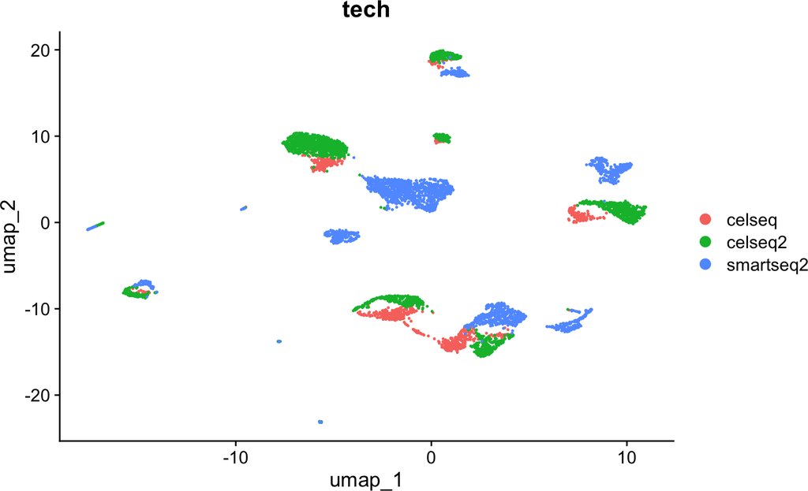

```r
DimPlot(seurat, group.by = "tech", reduction = "umap")
```

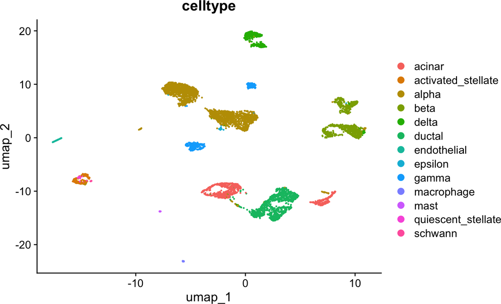

```r
DimPlot(seurat, group.by ="celltype", reduction = "umap")
```

# 5 Data analysis with batch correction

## 5.1 Batch correction using ComBat

First, we will test whether a simple linear method for batch correction does the job. We will use [ComBat](https://academic.oup.com/nargab/article/2/3/lqaa078/5909519)

Extract the RNA expression matrix and run ComBat:

```r
com <- ComBat(
  dat = t(FetchData(seurat, layer="scale.data", vars=VariableFeatures(seurat))),
  batch = seurat$tech
)
```

```
## Found 245 genes with uniform expression within a single batch (all zeros); these will not be adjusted for batch.
```

Create a new Seurat object and replace the RNA expression matrix by the ComBat-corrected data

```r
seurat.combat <- seurat
seurat.combat@assays$RNA@layers$scale.data <- com
```

Run PCA + UMAP

```r
seurat.combat <- RunPCA(seurat.combat, npcs = 30, verbose = FALSE)
seurat.combat <- RunUMAP(seurat.combat, reduction = "pca", dims = 1:30)
```

Plot UMAP

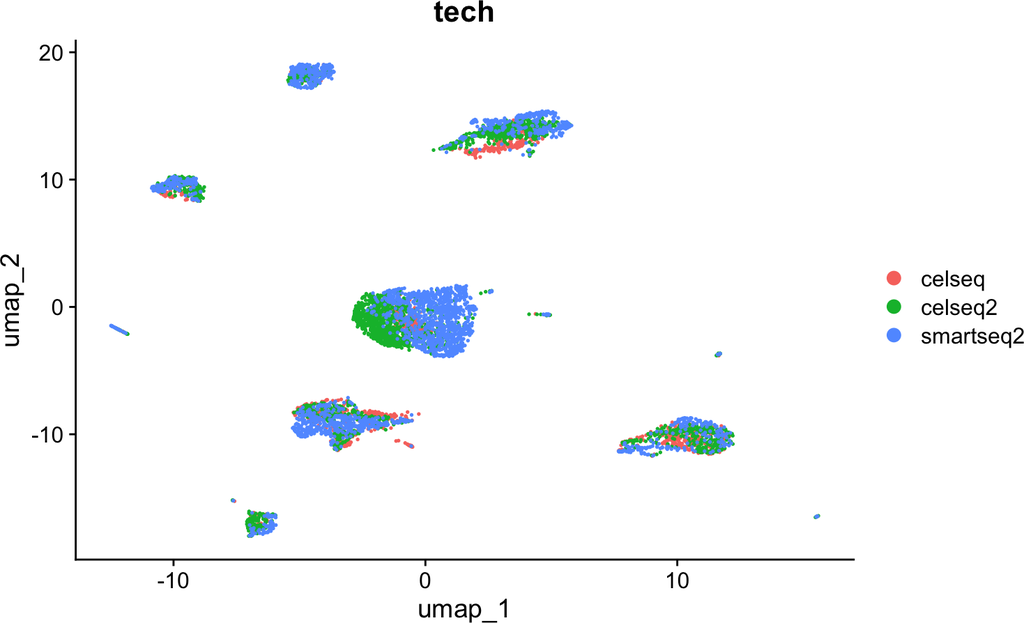

```r
DimPlot(seurat.combat, group.by = "tech", reduction = "umap")
```

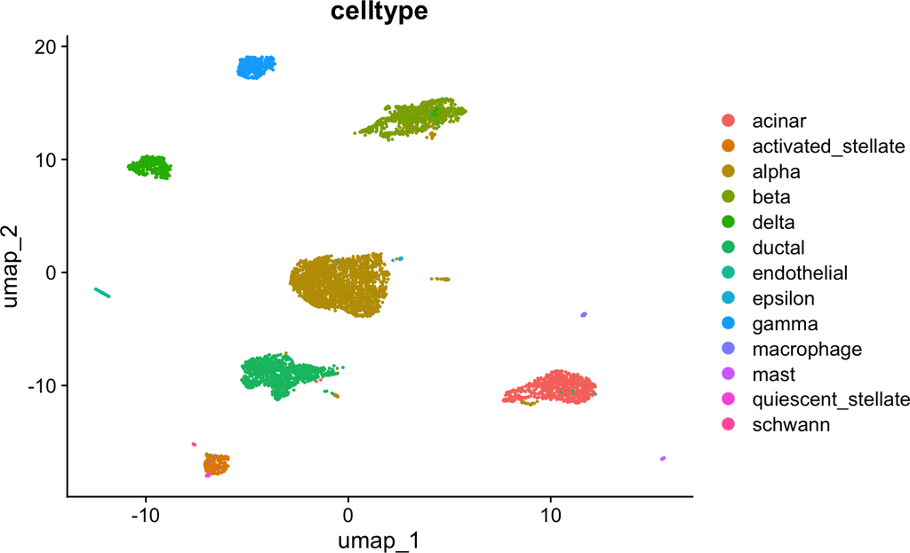

```r
DimPlot(seurat.combat, group.by ="celltype", reduction = "umap")
```

## 5.2 Batch correction using MNN (as implemented in Seurat)

Next, we can integrate the batches, here we only do this for three of them. For this, we identify anchors using an approach based on Canonical correlation analysis (CCA) with a given number of dimensions followed by MNN identification and then integrate the data by the resulting correction vectors. Seurat additionally downweights inconsistent pairs that might originate e.g. from mappings of a unique cell population in one batch.

**(Q) What are the differences between CCA and PCA? Why does it make sense to use CCA for batch correction?**

### 5.2.1 Prepare the data

First, split the Seurat object into a list of Seurat objects, one for each technology

```r
seurat.list <- SplitObject(seurat, split.by = "tech")
```

Perform the data normalization and feature selection for each batch separately.

```r
for (i in 1:length(seurat.list)) {

  # Normalisation
  seurat.list[[i]] <- NormalizeData(
    object = seurat.list[[i]],
    verbose = FALSE
  )

  # Feature selection
  seurat.list[[i]] <- FindVariableFeatures(
    object = seurat.list[[i]],
    selection.method = "vst",
    nfeatures = 2000,
    verbose = FALSE
  )
}
```

### 5.2.2 Find anchors

Then, do reduce the dimensionality of the data using CCA and then identify the “anchors” or the “mutual neighbours” between the different data sets (i.e. pairs of cells from each dataset that are contained within each other’s neighbourhood)

```r
anchors <- FindIntegrationAnchors(object.list = seurat.list, dims = 1:30)
anchors
```

```
## An AnchorSet object containing 20022 anchors between 3 Seurat objects
##  This can be used as input to IntegrateData.
```

### 5.2.3 Batch correction

The second part is to perform the actual batch correction. This involves four main (internal) computations:

- Step 1: construct a weights matrix that defines the similarity between each query cell and each anchor.
- Step 2: compute the anchor integration matrix as the difference between the two expression matrices for every pair of anchor cells.
- Step 3. compute the transformation matrix as the product of the integration matrix and the weights matrix.
- Step 4: Subtract the transformation matrix from the original expression matrix.

```r
seurat.integrated <- IntegrateData(anchorset = anchors, dims = 1:30)
```

### 5.2.4 Visualisation

Once integrated we can again perform dimensionality reduction on the batch-corrected data and plot a UMAP

Run but ignore this chunk

```r
DefaultAssay(seurat.integrated) <- "integrated"
seurat.integrated <- ScaleData(seurat.integrated, verbose = FALSE)
```

Run PCA + UMAP

```r
seurat.integrated <- RunPCA(seurat.integrated, npcs = 30, verbose = FALSE)
seurat.integrated <- RunUMAP(seurat.integrated, reduction = "pca", dims = 1:30)
```

Plot UMAP

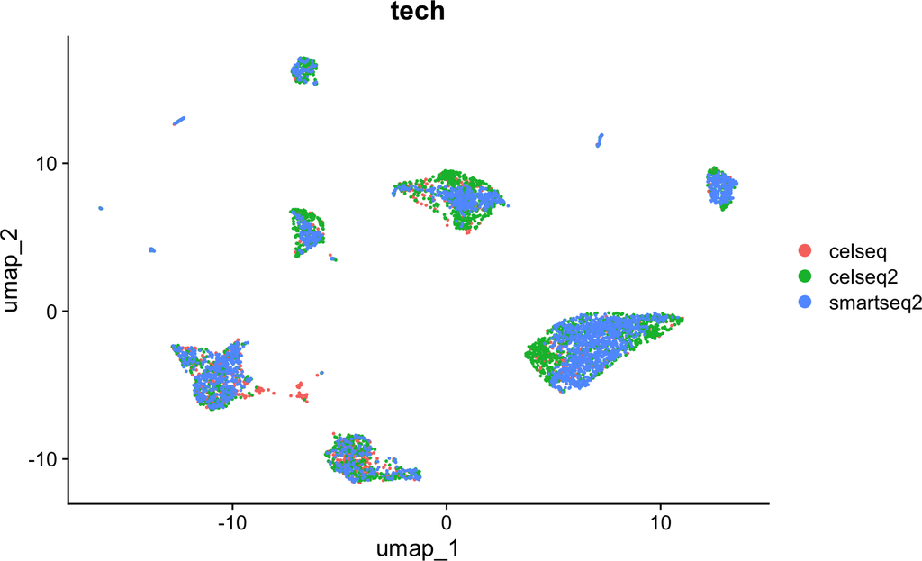

```r
DimPlot(seurat.integrated, reduction = "umap", group.by = "tech")
```

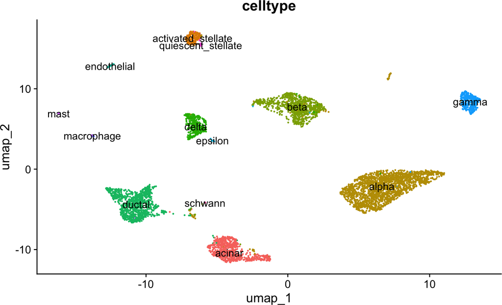

```r
DimPlot(seurat.integrated, reduction = "umap", group.by = "celltype", label = TRUE) + NoLegend()
```

**(Q) Compare the UMAPs obtained using Seurat’s MNN and ComBat. Which method has been more effective at removing the batch effects?**

**(Q) Why do we apply PCA (or CCA) before batch correction?**

# 6 Marker gene identification

**[TASK] Use the batch-corrected Seurat object to find differentially expressed genes between “alpha” and “beta” cells. Validate your predictions by visualising the expression patterns of the top differentially expressed genes**

**Solution**

```r
# Option 1
Idents(seurat.integrated) <- "celltype"
diff.genes <- FindMarkers(seurat.integrated, ident.1 = "alpha", ident.2 = "beta")
```

[output not shown]

```r
# Option 2
alpha.cells <- colnames(seurat)[seurat$celltype=="alpha"]
beta.cells <- colnames(seurat)[seurat$celltype=="beta"]
diff.genes <- FindMarkers(GetAssay(seurat.integrated), cells.1 = alpha.cells, cells.2 = beta.cells)
```

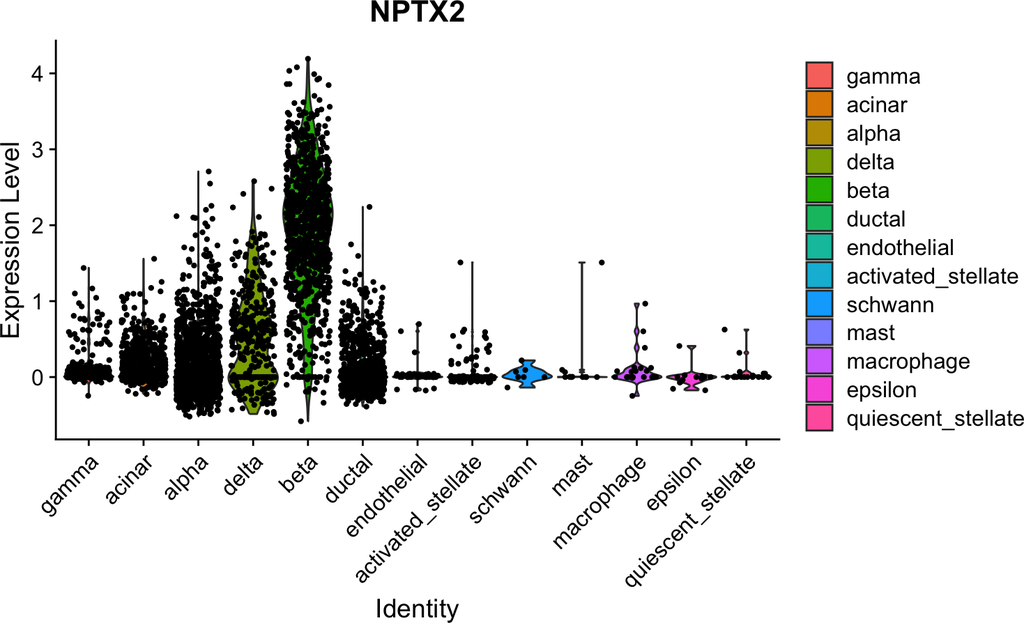

```r
genes.to.plot <- rownames(head(diff.genes,n=4))
VlnPlot(seurat.integrated, features=genes.to.plot[1])
```

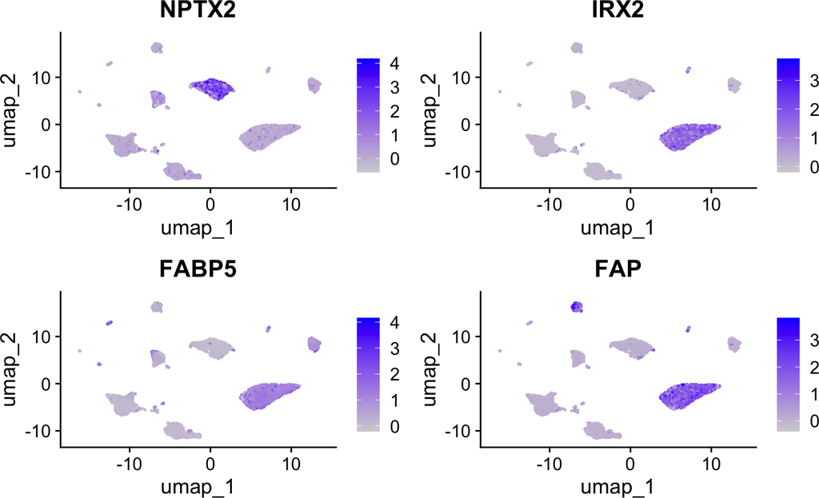

```r
FeaturePlot(seurat.integrated, features = genes.to.plot, reduction="umap")
```